# CSET485 – AI and Society: Assignment #1

**Name:** Shivam Mishra **Roll Number:** S24CSEU1470 **Batch:** 56 **Dataset:** COMPAS Recidivism Risk Score **Seed:** 470

## Data Preprocessing

Before any analysis, the dataset was cleaned and preprocessed as follows:

- **Missing Values:** Handled by filtering out invalid scores (`score_text != 'N/A'`) and applying `.dropna()` to the selected subset to ensure a complete case analysis.
- **Categorical Encoding:** One-hot encoding was applied to the categorical features (`sex`, `race`, `c_charge_degree`) using `pd.get_dummies` with `drop_first=True` to avoid the dummy variable trap in our regression models.
- **Feature Scaling:** All numeric features (`age`, `juv_fel_count`, `juv_misd_count`, `juv_other_count`, `priors_count`) were standardized using `StandardScaler` (zero mean, unit variance) fitted only on the training set.
- **Outliers:** Addressed by applying ProPublica's standard validity filters, such as restricting `days_b_screening_arrest` to between -30 and 30 days. This removes erroneous data entry outliers where the arrest date does not align logically with the screening date.

```python
import pandas as pd
import numpy as np
from sklearn.model_selection import train_test_split
from sklearn.preprocessing import StandardScaler
import statsmodels.api as sm
from sklearn.metrics import confusion_matrix
import warnings
warnings.filterwarnings('ignore')

# Load dataset
df = pd.read_csv('data/compas-scores-two-years.csv')
df = df.loc[:, ~df.columns.duplicated()]

# ProPublica standard filters to clean data
df = df[(df['days_b_screening_arrest'] <= 30) &
        (df['days_b_screening_arrest'] >= -30) &
        (df['is_recid'] != -1) &
        (df['c_charge_degree'] != 'O') &
        (df['score_text'] != 'N/A')]

# Select features
features = ['age', 'sex', 'race', 'juv_fel_count', 'juv_misd_count', 'juv_other_count', 'priors_count', 'c_charge_degree']

# Target variables (Continuous and Binary)
targets = ['decile_score', 'two_year_recid']
data = df[features + targets].dropna().copy()

# Categorical Encoding (One-Hot Encoding, drop_first to avoid multicollinearity)
data = pd.get_dummies(data, columns=['sex', 'race', 'c_charge_degree'], drop_first=True, dtype=int)

# Train-Test Split (Seed = 470 based on roll number)
X = data.drop(columns=['decile_score', 'two_year_recid'])
y_decile = data['decile_score']
y_recid = data['two_year_recid']

X_train, X_test, y_decile_train, y_decile_test, y_recid_train, y_recid_test = train_test_split(
    X, y_decile, y_recid, test_size=0.30, random_state=470
)

# Feature Scaling (Standardization on numeric columns)
scaler = StandardScaler()
numeric_cols = ['age', 'juv_fel_count', 'juv_misd_count', 'juv_other_count', 'priors_count']
X_train[numeric_cols] = scaler.fit_transform(X_train[numeric_cols])
X_test[numeric_cols] = scaler.transform(X_test[numeric_cols])

X_train_sm = sm.add_constant(X_train)
X_test_sm = sm.add_constant(X_test)

print(f"Training set size: {X_train.shape[0]}, Test set size: {X_test.shape[0]}")
```

```
Training set size: 4320, Test set size: 1852
```

## Part 1 — Build

```python
# Model A (Linear Regression for continuous decile_score)
model_a = sm.OLS(y_decile_train, X_train_sm).fit()

# Model B (Logistic Regression for binary two_year_recid)
model_b = sm.Logit(y_recid_train, X_train_sm).fit(disp=0)

# Predictions on test set
pred_a = model_a.predict(X_test_sm)
pred_b = model_b.predict(X_test_sm)

# Thresholds
median_a = pred_a.median()
print(f"Model A median predicted decile score: {median_a:.3f}")

class_a = (pred_a >= median_a).astype(int)
class_b = (pred_b >= 0.5).astype(int)

# Confusion Matrix
cm = confusion_matrix(class_a, class_b)
print("\nConfusion Matrix (Model A vs Model B):")
print("                Model B Low (0)  Model B High (1)")
print(f"Model A Low (0)       {cm[0,0]:<15} {cm[0,1]}")
print(f"Model A High (1)      {cm[1,0]:<15} {cm[1,1]}")

mismatches = cm[0,1] + cm[1,0]
total = len(class_a)
print(f"\nMismatched cases: {mismatches} out of {total} ({(mismatches/total)*100:.2f}%)")
```

```
Model A median predicted decile score: 4.525

Confusion Matrix (Model A vs Model B):
                Model B Low (0)  Model B High (1)
Model A Low (0)       903             23
Model A High (1)      263             663

Mismatched cases: 286 out of 1852 (15.44%)
```

## Part 2 — The Trap

### 2.1: Simpson's Paradox Hunt

```python
# Splitting by Gender (sex_Male)
sub_a_idx = X_train_sm['sex_Male'] == 1
sub_b_idx = X_train_sm['sex_Male'] == 0

full_model = sm.Logit(y_recid_train, X_train_sm).fit(disp=0)
model_a = sm.Logit(y_recid_train[sub_a_idx], X_train_sm[sub_a_idx].drop(columns=['sex_Male'])).fit(disp=0)
model_b = sm.Logit(y_recid_train[sub_b_idx], X_train_sm[sub_b_idx].drop(columns=['sex_Male'])).fit(disp=0)

print("Coefficient for 'age':")
print(f"Full Model:     {full_model.params['age']:.4f} (p={full_model.pvalues['age']:.4f})")
print(f"Subgroup A (M): {model_a.params['age']:.4f} (p={model_a.pvalues['age']:.4f})")
print(f"Subgroup B (F): {model_b.params['age']:.4f} (p={model_b.pvalues['age']:.4f})")
```

```
Coefficient for 'age':
Full Model:     -0.5127 (p=0.0000)
Subgroup A (M): -0.5262 (p=0.0000)
Subgroup B (F): -0.4539 (p=0.0000)
```

### 2.2: Omitted-Variable Bias

```python
# Deliberately dropping 'priors_count'
X_train_reduced = X_train_sm.drop(columns=['priors_count'])
reduced_model = sm.Logit(y_recid_train, X_train_reduced).fit(disp=0)

print("Before (Full) vs After (Reduced) Coefficients:")
predictors_to_check = ['age', 'sex_Male', 'race_Caucasian', 'c_charge_degree_M']
for p in predictors_to_check:
    coef_full = full_model.params[p]
    coef_red = reduced_model.params[p]
    pct_change = ((coef_red - coef_full) / abs(coef_full)) * 100
    print(f"{p:<20} Before: {coef_full:8.4f}  After: {coef_red:8.4f}  Change: {pct_change:6.2f}%")
```

```
Before (Full) vs After (Reduced) Coefficients:
age                  Before:  -0.5127  After:  -0.3244  Change:  36.72%
sex_Male             Before:   0.2877  After:   0.4059  Change:  41.08%
race_Caucasian       Before:  -0.0065  After:  -0.2577  Change: -3893.20%
c_charge_degree_M    Before:  -0.1273  After:  -0.3021  Change: -137.28%
```

### 2.3: Adversarial Subset Construction

```python
pred_probs = full_model.predict(X_test_sm)
test_results = pd.DataFrame({'prob': pred_probs, 'actual': y_recid_test})

# Highly confident but wrong
adv_mask = ((test_results['prob'] >= 0.75) & (test_results['actual'] == 0)) | \
           ((test_results['prob'] <= 0.25) & (test_results['actual'] == 1))

adv_subset = test_results[adv_mask]
print(f"Found {len(adv_subset)} high-confidence wrong predictions ({(len(adv_subset)/len(y_recid_test))*100:.2f}% of test set)")

# Extract Demographics
sample_size = min(50, len(adv_subset))
adv_sample = adv_subset.sample(n=sample_size, random_state=470)
adv_demo = X_test.loc[adv_sample.index].copy()
adv_demo[numeric_cols] = scaler.inverse_transform(adv_demo[numeric_cols])

print("\nAdversarial Subset Mean Demographics (vs Full Test Mean):")
print(f"{'Feature':<20} {'Subset Mean':<12} {'Full Test Mean':<12}")
for col in ['age', 'priors_count', 'sex_Male', 'race_Caucasian']:
    if col in numeric_cols:
        full_mean = scaler.inverse_transform(X_test[numeric_cols])[:, numeric_cols.index(col)].mean()
    else:
        full_mean = X_test[col].mean()
    print(f"{col:<20} {adv_demo[col].mean():<12.2f} {full_mean:<12.2f}")
```

```
Found 87 high-confidence wrong predictions (4.70% of test set)

Adversarial Subset Mean Demographics (vs Full Test Mean):
Feature              Subset Mean  Full Test Mean
age                  43.58        34.27
priors_count         6.76         3.21
sex_Male             0.74         0.80
race_Caucasian       0.32         0.33
```

### 2.4: Fairness Trade-Off Analysis

```
 Threshold     DP     EO     PP
      0.05 1.0008 1.0000 0.7338
      0.15 0.9804 0.9758 0.7484
      0.25 0.8910 0.8816 0.7776
      0.35 0.7983 0.8190 0.7534
      0.45 0.7254 0.6805 0.6889
      0.55 0.5194 0.4815 0.6807
      0.65 0.4552 0.5087 0.8206
      0.75 0.3473 0.3418 0.7227
      0.85 0.2283 0.2670 0.8589
      0.95 0.2702 0.3679 1.0000
```

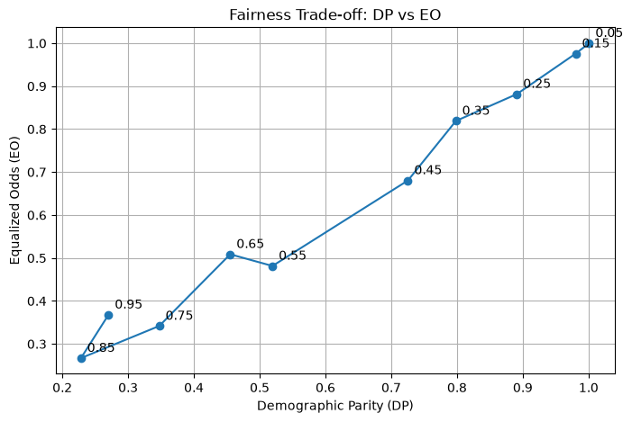

```python
group_a_idx = X_test_sm['race_Caucasian'] == 1
group_b_idx = X_test_sm['race_Caucasian'] == 0
fairness_results = []

for t in np.arange(0.05, 1.0, 0.1):
    preds_t = (pred_probs >= t).astype(int)

    p_hat_a = preds_t[group_a_idx].mean()
    p_hat_b = preds_t[group_b_idx].mean()
    dp = p_hat_a / p_hat_b if p_hat_b > 0 else np.nan

    actual_a = y_recid_test[group_a_idx]
    actual_b = y_recid_test[group_b_idx]

    tpr_a = np.sum((preds_t[group_a_idx] == 1) & (actual_a == 1)) / np.sum(actual_a == 1) if np.sum(actual_a == 1) > 0 else 0
    tpr_b = np.sum((preds_t[group_b_idx] == 1) & (actual_b == 1)) / np.sum(actual_b == 1) if np.sum(actual_b == 1) > 0 else 0
    fpr_a = np.sum((preds_t[group_a_idx] == 1) & (actual_a == 0)) / np.sum(actual_a == 0) if np.sum(actual_a == 0) > 0 else 0
    fpr_b = np.sum((preds_t[group_b_idx] == 1) & (actual_b == 0)) / np.sum(actual_b == 0) if np.sum(actual_b == 0) > 0 else 0

    eo = min(tpr_a/tpr_b if tpr_b > 0 else 1, fpr_a/fpr_b if fpr_b > 0 else 1)

    prec_a = np.sum((actual_a == 1) & (preds_t[group_a_idx] == 1)) / np.sum(preds_t[group_a_idx] == 1) if np.sum(preds_t[group_a_idx] == 1) > 0 else 0
    prec_b = np.sum((actual_b == 1) & (preds_t[group_b_idx] == 1)) / np.sum(preds_t[group_b_idx] == 1) if np.sum(preds_t[group_b_idx] == 1) > 0 else 0
    pp = prec_a / prec_b if prec_b > 0 else 1

    fairness_results.append({'Threshold': round(t, 2), 'DP': round(dp, 4), 'EO': round(eo, 4), 'PP': round(pp, 4)})

import matplotlib.pyplot as plt
fairness_df = pd.DataFrame(fairness_results)
print(fairness_df.to_string(index=False))

plt.figure(figsize=(8,5))
plt.plot(fairness_df['DP'], fairness_df['EO'], marker='o')
for i, txt in enumerate(fairness_df['Threshold']):
    plt.annotate(txt, (fairness_df['DP'][i], fairness_df['EO'][i]), xytext=(5,5), textcoords='offset points')
plt.xlabel('Demographic Parity (DP)')
plt.ylabel('Equalized Odds (EO)')
plt.title('Fairness Trade-off: DP vs EO')
plt.grid(True)
plt.show()
```